# modelAndEDA FINAL pdf

### Model 2: Gradient Boosting Classifier

```python
from sklearn.ensemble import GradientBoostingClassifier
gbc = GradientBoostingClassifier()
gbc.fit(X_train, y_train)
```

```
GradientBoostingClassifier()
```

```python
gbc_train_score = gbc.score(X_train, y_train)
print(f'Accuracy Score on Training Set: {gbc_train_score}')
```

```
Accuracy Score on Training Set: 0.985553772070626
```

```python
gbc_test_score = gbc.score(X_test, y_test)
print(f'Accuracy Score on Test Set: {gbc_test_score}')
```

```
Accuracy Score on Test Set: 0.8846153846153846
```

```python
predictions_gbc = gbc.predict(X_test)
gbc_cross_val_scores = cross_val_score(gbc, X_recombined, y_recombined, cv=k_folds)
print(f'Gradient Boosting Classifier Cross-Validation Scores: {gbc_cross_val_scores}')
print(f'Gradient Boosting Classifier Mean CV Score: {gbc_cross_val_scores.mean()}')
```

```
Gradient Boosting Classifier Cross-Validation Scores: [0.8974359  0.8974359  0.83333333 0.8974359  0.94871795 0.94871795
 0.94871795 0.80769231 0.84615385 0.8961039 ]
Gradient Boosting Classifier Mean CV Score: 0.8921744921744921
```

```python
overfit_underfit_analysis(gbc_train_score, gbc_cross_val_scores.mean())
```

```
Training Score: 0.985553772070626
Cross Validation Score: 0.8921744921744921
The model is overfitting.
Difference: 0.09337927989613393
```

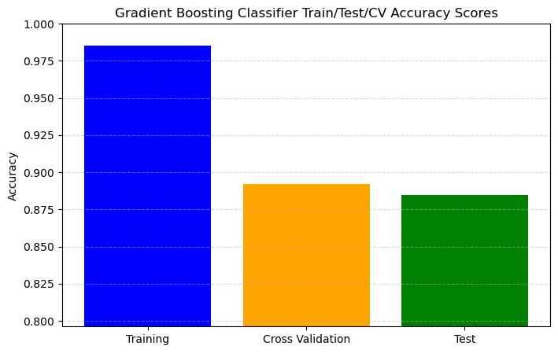

```python
import matplotlib.pyplot as plt

scores = [
    gbc_train_score,
    gbc_cross_val_scores.mean(),
    gbc_test_score
]

labels = ['Training', 'Cross Validation', 'Test']

plt.figure(figsize=(8,5))
plt.bar(labels, scores, color=['blue', 'orange', 'green'])
plt.ylim(0.9 * min(scores), 1)# (ChatGPT, 2025)
plt.ylabel("Accuracy")
plt.title("Gradient Boosting Classifier Train/Test/CV Accuracy Scores")
plt.grid(axis='y', linestyle='--', alpha=0.5)
plt.show()
```

### Hyperparameter Tuning for Gradient Boosting Classifier

Our analysis of the gradient boosting classifier has revealed some considerable overfitting, as indicated by the higher training score compared to cross-validation score. To combat this, I will explore hyperparameter tuning to improve model generalization. This will require changes to tree depth and number of estimators (number of trees in our ensemble). This will help us find the optimal balance between bias and variance, allowing for better performance on unseen data. I will use a grid search to systematically explore combinations of these hyperparameters and identify the best configuration for our model (figure 20).

| Hyperparameter | What it does | Effect on our Overfitting problem |
| --- | --- | --- |
| `max_depth` | Limits the maximum depth of each tree. Deeper trees capture more complex patterns but are more likely to overfit. | Shallower → reduces overfitting. |
| `max_leaf_nodes` | Sets the maximum number of leaf nodes per tree. More leaves allow for more complex patterns, increasing overfitting risk. | Fewer leaves → reduces overfitting. |
| `min_samples_leaf` | Minimum number of samples required at a leaf node. Higher values prevent very small leaves, reducing overfitting. | Higher → reduces overfitting. |
| `min_samples_split` | Minimum number of samples required to split a node. Larger values prevent splits on tiny nodes, reducing overfitting. | Higher → reduces overfitting. |
| `learning_rate` | Shrinks contribution of each tree in the ensemble. Smaller values slow learning but reduce overfitting. | Smaller → reduces overfitting. |
| `n_estimators` | Number of boosting iterations (trees). More trees can increase complexity and overfitting, especially with high learning rates. | Fewer trees → reduces overfitting. |

Figure 20: Gradient Boosting Classifier Hyperparameter Explanations

#### Tree depth and number of estimators tuning

```python
hyperparameters = {
    'max_depth': 6, #limit tree depth to reduce overfitting
    'n_estimators': 150,#reduce number of trees to prevent overfitting
}

# Previous hyperparameter attempts:
# hyperparameters = {
#     'max_depth': 5,
#     'n_estimators': 200,
# }
# hyperparameters = {
#     'max_depth': 4,
#     'n_estimators': 100,
# }
# hyperparameters = {
#     'max_depth': 3,
#     'n_estimators': 200,
# }
# hyperparameters = {
#     'max_depth': 7,
#     'n_estimators': 200,
# }
```

```python
gbc_tuned = GradientBoostingClassifier(**hyperparameters)
gbc_tuned.fit(X_train, y_train)
```

```
GradientBoostingClassifier(max_depth=6, n_estimators=150)
```

```python
gbc_tuned_train_score = gbc_tuned.score(X_train, y_train)
print(f'Accuracy Score on Training Set: {gbc_tuned_train_score}')
gbc_tuned_test_score = accuracy_score(y_test, gbc_tuned.predict(X_test))
print(f'Accuracy Score on Test Set: {gbc_tuned_test_score}')
```

```
Accuracy Score on Training Set: 1.0
Accuracy Score on Test Set: 0.8910256410256411
```

```python
gbc_tuned_cross_val_scores = cross_val_score(gbc_tuned, X_recombined, y_recombined, cv=k_folds)
print(f'Gradient Boosting Classifier Tuned Cross-Validation Scores: {gbc_tuned_cross_val_scores}')
print(f'Gradient Boosting Classifier Tuned Mean CV Score: {gbc_tuned_cross_val_scores.mean()}')
```

```
Gradient Boosting Classifier Tuned Cross-Validation Scores: [0.8974359  0.91025641 0.80769231 0.88461538 0.92307692 0.91025641
 0.94871795 0.85897436 0.85897436 0.90909091]
Gradient Boosting Classifier Tuned Mean CV Score: 0.8909090909090909
```

```python
overfit_underfit_analysis(gbc_tuned_train_score, gbc_tuned_cross_val_scores.mean())
```

```
Training Score: 1.0
Cross Validation Score: 0.8909090909090909
The model is overfitting.
Difference: 0.10909090909090913
```

```python
print(f'Previous Gradient Boosting Classifier Mean CV Score: {gbc_cross_val_scores.mean()}')
print(f'Tuned Gradient Boosting Classifier Mean CV Score: {gbc_tuned_cross_val_scores.mean()}')
print(f'Improvement in Mean CV Score after Tuning: {gbc_tuned_cross_val_scores.mean() - gbc_cross_val_scores.mean()}')
```

```
Previous Gradient Boosting Classifier Mean CV Score: 0.8921744921744921
Tuned Gradient Boosting Classifier Mean CV Score: 0.8909090909090909
Improvement in Mean CV Score after Tuning: -0.0012654012654012003
```

#### Hyperparameter Optimization and Visualization

```python
hyperparameters = { #
    'max_depth':[1,2,5,6,7,8],
    'n_estimators':[50,100,150,200],
    'min_samples_split':[2,4,8,12],
    'min_samples_leaf':[2,4,6,8],
    'max_leaf_nodes':[20,30,40,60],
    'learning_rate':[0.01,0.05,0.1, 0.5]
}

results = {}
for param, values in hyperparameters.items(): #Loop through each hyperparameter, to see its effect individually
    scores = []
    for val in values:
        params = {param: None}
        params[param] = val
        model = GradientBoostingClassifier(**params)
        cv = cross_val_score(model, X_recombined, y_recombined, cv=k_folds)
        scores.append(cv.mean())
    results[param] = (values, scores)
```

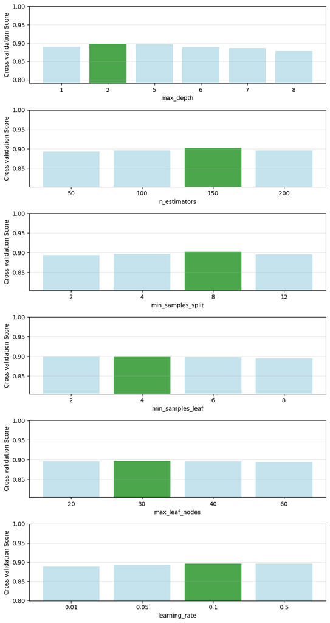

```python
fig, axes = plt.subplots(6, 1, figsize=(8, 15))

for i, param in enumerate(hyperparameters.keys()):
    scores = results[param][1]
    best_idx = scores.index(max(scores))
    colors = ['green' if j == best_idx else 'lightblue' for j in range(len(scores))] # (ChatGPT, 2025)
    axes[i].bar(range(len(results[param][0])), results[param][1], color=colors, alpha=0.7)
    axes[i].set_xlabel(param)
    axes[i].set_ylabel('Cross validation Score')
    axes[i].set_xticks(range(len(results[param][0])))
    axes[i].set_xticklabels(results[param][0])
    axes[i].set_ylim(0.9 * min(results[param][1]), 1)
    axes[i].grid(True, alpha=0.3, axis='y')

plt.tight_layout()
plt.show()
```

#### Grid Search for Hyperparameter Optimization

```python
grid_search_gbc = GridSearchCV(GradientBoostingClassifier(), hyperparameters, cv=k_folds)
grid_search_gbc.fit(X_recombined, y_recombined)
grid_searched_best_model_gbc = grid_search_gbc.best_estimator_ # Uses cross validation to find best model hyperparameters
```

```python
print(f'Best Hyperparameters from Grid Search: {grid_search_gbc.best_params_}')
grid_search_gbc_train_score = grid_searched_best_model_gbc.score(X_train, y_train)
print(f'Accuracy Score on Training Set: {grid_search_gbc_train_score}')
grid_search_gbc_test_score = accuracy_score(y_test, grid_searched_best_model_gbc.predict(X_test))
print(f'Accuracy Score on Test Set: {grid_search_gbc_test_score}')
grid_searched_gbc_cross_val_scores = cross_val_score(grid_searched_best_model_gbc, X_recombined, y_recombined, cv=k_folds)
print(f'Grid Searched Gradient Boosting Classifier Cross-Validation Scores: {grid_searched_gbc_cross_val_scores}')
print(f'Grid Searched Gradient Boosting Classifier Mean CV Score: {grid_searched_gbc_cross_val_scores.mean()}')
overfit_underfit_analysis(grid_search_gbc_train_score, grid_searched_gbc_cross_val_scores.mean())
```

```
Best Hyperparameters from Grid Search: {'learning_rate': 0.1, 'max_depth': 8, 'max_leaf_nodes': 40, 'min_samples_leaf': 4, 'min_samples_split': 8, 'n_estimators': 150}
Accuracy Score on Training Set: 1.0
Accuracy Score on Test Set: 0.9230769230769231
Grid Searched Gradient Boosting Classifier Cross-Validation Scores: [0.91025641 0.93589744 0.83333333 0.91025641 0.92307692 0.94871795
 0.94871795 0.83333333 0.85897436 0.92207792]
Grid Searched Gradient Boosting Classifier Mean CV Score: 0.9024642024642023
Training Score: 1.0
Cross Validation Score: 0.9024642024642023
The model is overfitting.
Difference: 0.09753579753579766
```

```python
best_params = pd.DataFrame(grid_search_gbc.best_params_, index=[0])
print(f'Grid Search Best Hyperparameters:\n{best_params}')
```

```
Grid Search Best Hyperparameters:
   learning_rate  max_depth  max_leaf_nodes  min_samples_leaf  \
0            0.1          8              40                 4

   min_samples_split  n_estimators
0                  8           150
```

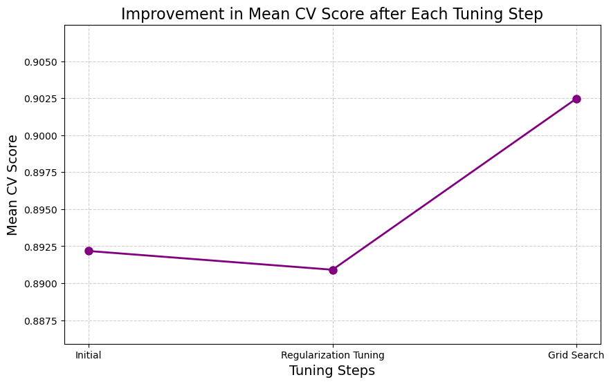

```python
import matplotlib.pyplot as plt

tuning_steps = ['Initial', 'Regularization Tuning', 'Grid Search']
mean_cv_scores = [
    gbc_cross_val_scores.mean(), # Model before tuning
    gbc_tuned_cross_val_scores.mean(), # Model after manual hyperparameter tuning (experimental)
    grid_searched_gbc_cross_val_scores.mean() # Model after grid search tuning
]
plt.figure(figsize=(10,6))
plt.plot(tuning_steps, mean_cv_scores, marker='o', linestyle='-', color='purple', linewidth=2, markersize=8)

plt.title('Improvement in Mean CV Score after Each Tuning Step', fontsize=16)
plt.xlabel('Tuning Steps', fontsize=14)
plt.ylabel('Mean CV Score', fontsize=14)

# Zoom in on the range of scores to make small improvements more visible
plt.ylim(min(mean_cv_scores)-0.005, max(mean_cv_scores)+0.005) #(ChatGPT, 2025)

plt.grid(True, linestyle='--', alpha=0.6)
plt.show()
```

```python
print(f'Previous Best Tuned Gradient Boosting Classifier Mean CV Score: {gbc_tuned_cross_val_scores.mean()}')
print(f'Grid Searched Gradient Boosting Classifier Mean CV Score: {grid_searched_gbc_cross_val_scores.mean()}')
print(f'Improvement in Mean CV Score after Grid Search: {grid_searched_gbc_cross_val_scores.mean() - gbc_tuned_cross_val_scores.mean()}')
```

```
Previous Best Tuned Gradient Boosting Classifier Mean CV Score: 0.8909090909090909
Grid Searched Gradient Boosting Classifier Mean CV Score: 0.9024642024642023
Improvement in Mean CV Score after Grid Search: 0.011555111555111464
```

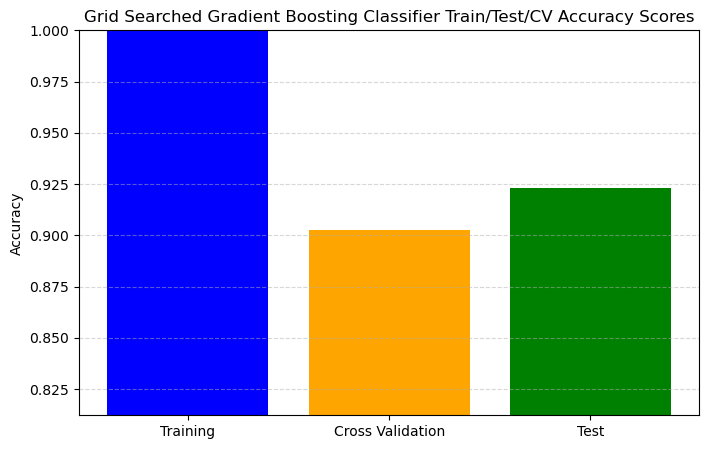

```python
import matplotlib.pyplot as plt

scores = [
    grid_search_gbc_train_score,
    grid_searched_gbc_cross_val_scores.mean(),
    grid_search_gbc_test_score
]

labels = ['Training', 'Cross Validation', 'Test']

plt.figure(figsize=(8,5))
plt.bar(labels, scores, color=['blue', 'orange', 'green'])
plt.ylim(0.9 * min(scores), 1)# (ChatGPT, 2025)
plt.ylabel("Accuracy")
plt.title("Grid Searched Gradient Boosting Classifier Train/Test/CV Accuracy Scores")
plt.grid(axis='y', linestyle='--', alpha=0.5)
plt.show()
```

```python
gbc_top_perf = grid_searched_best_model_gbc #top preforming model after hyperparameter tuning
```

```python
with open('gradient_decsion_tree_scores.txt', 'w') as f:
    f.write(f'Best Gradient Boosting Classifier Mean CV Score: {grid_searched_gbc_cross_val_scores.mean()}')
    for i, score in enumerate(grid_searched_gbc_cross_val_scores):
        f.write(f'\nFold {i+1} CV Score: {score}')
    f.close()
```

## Results and Evaluation

```python
print('Results Summary for Top Performing Models:')
print('\n')
print('Logistic Regression Classifier:')
print(f"Training Score: {grid_searched_logclf_train_score}")
print(f" Test Score: {grid_searched_logclf_test_score}")
print(f" Mean CV Score: {grid_searched_logclf_cross_val_scores.mean()}")
print('\n')
print('Gradient Boosting Classifier:')
print(f"Training Score: {grid_search_gbc_train_score}")
print(f" Test Score: {grid_search_gbc_test_score}")
print(f" Mean CV Score: {grid_searched_gbc_cross_val_scores.mean()}")
mean_cv_score_difference = grid_searched_logclf_cross_val_scores.mean() - grid_searched_gbc_cross_val_scores.mean()
```

```
Results Summary for Top Performing Models:


Logistic Regression Classifier:
Training Score: 0.8780096308186196
 Test Score: 0.9038461538461539
 Mean CV Score: 0.8703296703296702


Gradient Boosting Classifier:
Training Score: 1.0
 Test Score: 0.9230769230769231
 Mean CV Score: 0.9024642024642023
```

```python
if mean_cv_score_difference > 0:
    print(f'Logistic Regression outperforms Gradient Boosting Classifier by {mean_cv_score_difference} on cross validation.')
else:
    print(f'Gradient Boosting Classifier outperforms Logistic Regression by {-mean_cv_score_difference} om cross validation.')
```

```
Gradient Boosting Classifier outperforms Logistic Regression by 0.0321345321345321 om cross validation.
```

```python
print('Overfit/Underfit Analysis for Top Performing Models:')
print("Logistic Regression Overfit/Underfit Analysis:")
overfit_underfit_analysis(grid_searched_logclf_train_score, grid_searched_logclf_cross_val_scores.mean())
print ("\n")
print("Gradient Boosting Classifier Overfit/Underfit Analysis:")
overfit_underfit_analysis(grid_search_gbc_train_score, grid_searched_gbc_cross_val_scores.mean())
```

```
Overfit/Underfit Analysis for Top Performing Models:
Logistic Regression Overfit/Underfit Analysis:
Training Score: 0.8780096308186196
Cross Validation Score: 0.8703296703296702
The model has a good fit.


Gradient Boosting Classifier Overfit/Underfit Analysis:
Training Score: 1.0
Cross Validation Score: 0.9024642024642023
The model is overfitting.
Difference: 0.09753579753579766
```

### Training, Validation, and Test Performance comparison

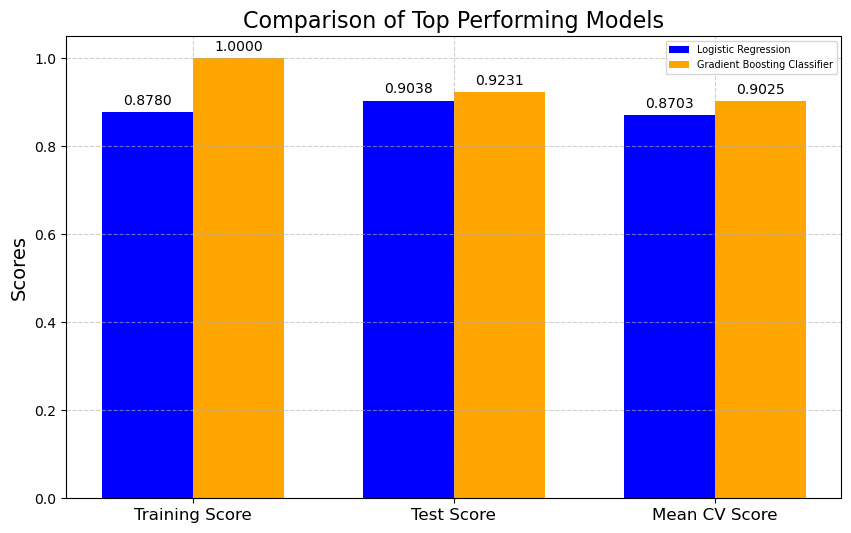

```python
import numpy as np
labels = ['Training Score', 'Test Score', 'Mean CV Score']
logclf_scores = [grid_searched_logclf_train_score, grid_searched_logclf_test_score, grid_searched_logclf_cross_val_scores.mean()]
gbc_scores = [grid_search_gbc_train_score, grid_search_gbc_test_score, grid_searched_gbc_cross_val_scores.mean()]
x = np.arange(len(labels))  # the label locations
width = 0.35  # the width of the bars
fig, ax = plt.subplots(figsize=(10,6))
bars1 = ax.bar(x - width/2, logclf_scores, width, label='Logistic Regression', color='blue') #ChatGPT, 2025
bars2 = ax.bar(x + width/2, gbc_scores, width, label='Gradient Boosting Classifier', color='orange') #ChatGPT, 2025
ax.set_ylabel('Scores', fontsize=14)
ax.set_title('Comparison of Top Performing Models', fontsize=16)
ax.set_xticks(x)
ax.set_xticklabels(labels, fontsize=12)
ax.legend(fontsize=7)
def autolabel(bars):
    """Attach a text label above each bar in *bars*, displaying its height."""
    for bar in bars: #ChatGPT, 2025
        height = bar.get_height()
        ax.annotate(f'{height:.4f}',
                    xy=(bar.get_x() + bar.get_width() / 2, height),
                    xytext=(0, 3),  # 3 points vertical offset
                    textcoords="offset points",
                    ha='center', va='bottom', fontsize=10)
autolabel(bars1)
autolabel(bars2)
plt.grid(True, linestyle='--', alpha=0.6)
plt.show()
```

Figure 21: Training, Validation, and Test Accuracy

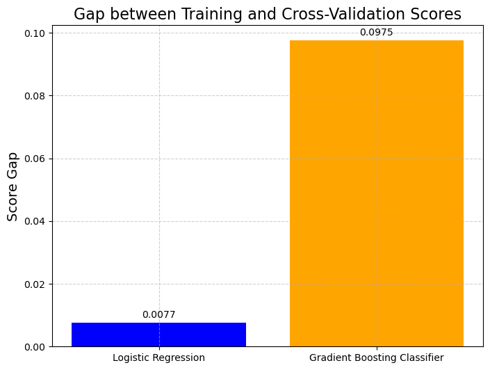

```python
models = ['Logistic Regression', 'Gradient Boosting Classifier']
gaps = [
    grid_searched_logclf_train_score - grid_searched_logclf_cross_val_scores.mean(),
    grid_search_gbc_train_score - grid_searched_gbc_cross_val_scores.mean()
]
plt.figure(figsize=(8,6))
bars = plt.bar(models, gaps, color=['blue', 'orange'])
plt.title('Gap between Training and Cross-Validation Scores', fontsize=16)
plt.ylabel('Score Gap', fontsize=14)
for bar in bars: #ChatGPT, 2025
    height = bar.get_height()
    plt.annotate(f'{height:.4f}',
                 xy=(bar.get_x() + bar.get_width() / 2, height),
                    xytext=(0, 3),  # 3 points vertical offset
                    textcoords="offset points",
                    ha='center', va='bottom', fontsize=10)
plt.grid(True, linestyle='--', alpha=0.6)
plt.show()
```

Figure 22: Training–Validation Accuracy Gap for Both Models

### Precision, Recall, and F1-Score comparison

```python
from sklearn.metrics import precision_score, recall_score
logclf_predictions = logclf_top_perf.predict(X_test)
logclf_precision = precision_score(y_test, logclf_predictions)
logclf_recall = recall_score(y_test, logclf_predictions)
print(f'Logistic Regression Precision: {logclf_precision}')
print(f'Logistic Regression Recall: {logclf_recall}')
```

```
Logistic Regression Precision: 0.8169014084507042
Logistic Regression Recall: 0.9666666666666667
```

```python
gbc_predictions = gbc_top_perf.predict(X_test)
gbc_precision = precision_score(y_test, gbc_predictions)
gbc_recall = recall_score(y_test, gbc_predictions)
print(f'Gradient Boosting Classifier Precision: {gbc_precision}')
print(f'Gradient Boosting Classifier Recall: {gbc_recall}')
```

```
Gradient Boosting Classifier Precision: 0.9
Gradient Boosting Classifier Recall: 0.9
```

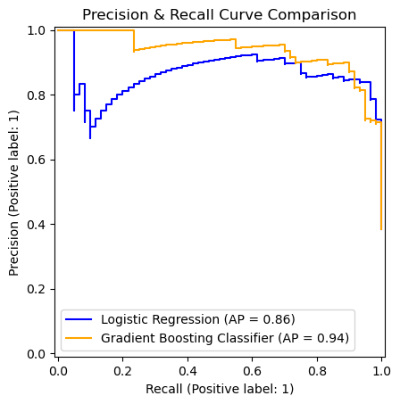

```python
from sklearn.metrics import PrecisionRecallDisplay
logclf_disp = PrecisionRecallDisplay.from_estimator(logclf_top_perf, X_test, y_test, name="Logistic Regression", color='blue')
gbc_disp = PrecisionRecallDisplay.from_estimator(gbc_top_perf, X_test, y_test, name="Gradient Boosting Classifier", color='orange', ax=logclf_disp.ax_)
logclf_disp.ax_.set_title('Precision & Recall Curve Comparison')
plt.show()
```

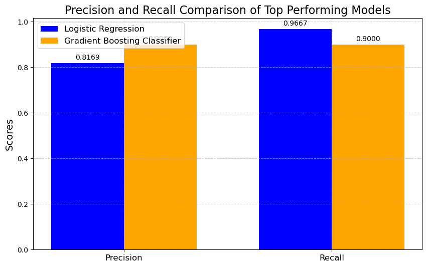

```python
import numpy as np
labels = ['Precision', 'Recall']
logclf_scores = [logclf_precision, logclf_recall]
gbc_scores = [gbc_precision, gbc_recall]
x = np.arange(len(labels))  # the label locations
width = 0.35  # the width of the bars
fig, ax = plt.subplots(figsize=(10,6))
bars1 = ax.bar(x - width/2, logclf_scores, width, label='Logistic Regression', color='blue') #ChatGPT, 2025
bars2 = ax.bar(x + width/2, gbc_scores, width, label='Gradient Boosting Classifier', color='orange') #ChatGPT, 2025

# Add some text for labels, title and custom x-axis tick labels, etc.
ax.set_ylabel('Scores', fontsize=14)
ax.set_title('Precision and Recall Comparison of Top Performing Models', fontsize=16)
ax.set_xticks(x)
ax.set_xticklabels(labels, fontsize=12)
ax.legend(fontsize=12)
# Attach a text label above each bar in *bars*, displaying its height.
def autolabel(bars):
    """Attach a text label above each bar in *bars*, displaying its height."""
    for bar in bars: ##ChatGPT, 2025
        height = bar.get_height()
        ax.annotate(f'{height:.4f}',
                    xy=(bar.get_x() + bar.get_width() / 2, height),
                    xytext=(0, 3),  # 3 points vertical offset
                    textcoords="offset points",
                    ha='center', va='bottom', fontsize=10)
autolabel(bars1)
autolabel(bars2)
plt.grid(True, linestyle='--', alpha=0.6)
plt.show()
```

Figure 24: Precision and Recall for Both Models

```python
from sklearn.metrics import f1_score
logclf_f1 = f1_score(y_test, logclf_predictions)
gbc_f1 = f1_score(y_test, gbc_predictions)
print(f'Logistic Regression F1 Score: {logclf_f1}')
print(f'Gradient Boosting Classifier F1 Score: {gbc_f1}')
```

```
Logistic Regression F1 Score: 0.8854961832061069
Gradient Boosting Classifier F1 Score: 0.9
```